# Assignment 3

Manuela Giansante

2023-03-17

```r
# Load ,libraries
library(fpp3)
library(fpp2)
library(fable)
library(tidyverse)
library(cowplot)
library(forecast)
library(fabletools)
library(kableExtra)
```

```r
# Initialize the paperback sales and hardcover sales
# from the Books dataset
paperback <- books[,1]
hardcover <- books[,2]
```

```r
times <- seq(1, dim(books)[1], 1)    # vector for time
books_df <- data.frame(books[, 1:2]) # Paperback and Hardcover as data.frame

# As a tsibble object
books_tsibble <- books_df %>%
  mutate(Time = times, .before=1) %>%
  as_tsibble(index = Time)
```

##### Paperbacks Sales Series

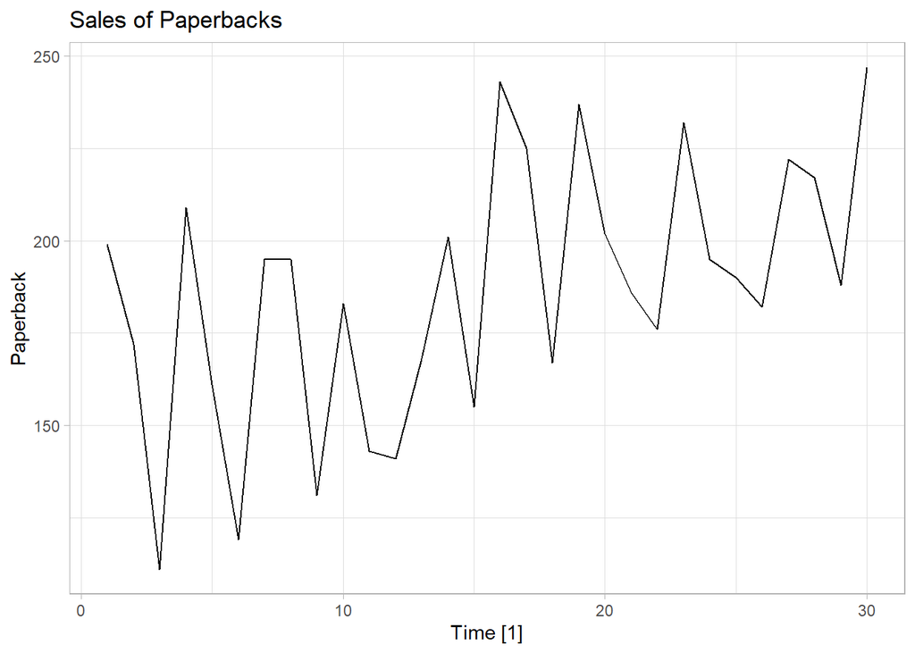

```r
autoplot(books_tsibble[,c(1,2)]) +
  labs(title = "Sales of Paperbacks",ylab="Sales of Paperbacks" )+
  theme_light()
```

#### Hardcovers Sales Series

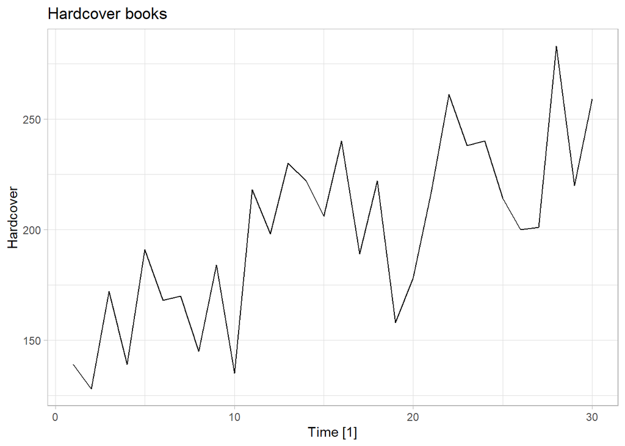

```r
autoplot(books_tsibble[,c(1,3)])+
  labs(title = "Hardcover books", ylab="Sales of Hardcovers")+
  theme_light()
```

Hardcover sales start at a lower point to then end above paperbacks sales in the last period. Paperback books’ sales experience more fluctuations than Hardcovers, they also seem to grow less but more steadily compared to hardcovers sales.

### a. Set the two Holt’s model with additive ETS(A,A,N)

The ETS(A,A,N) model, with additive error and trend and no seasonality, follows:

$\begin{aligned}y_{t}&=l_{t-1}+b_{t-1}+E _{t}\\l_{t}&=l_{t-1}+b_{t-1}+\alpha E_{t}\\b_{t}&=t_{t-1}+\beta E_{t}\end{aligned}$

Where $\beta$ is the smoothing parameter for the trend. The trend in this case in this case changes over time (intercept and slope vary), as we will see when plotting out the components of the model.

The error $E_t$ polluting the observations of the state is modelled in additive form. Since the trend and error are additive, we can reconcile the point forecasts to conditional expectations: $L_t=E(y_{t+1}|y_{(t)})$.

Where $y_{t+1}=L_t+E_{t+1}$, because we assume that the error $E_{t+1}$ is independent and normally distributed, therefore $E(E_{t+1}|y_{(t)})=0$.

#### a.1 Paperbacks

```r
# Fitting the AAN model
paperback_model <- books_tsibble[,c(1,2)] %>%
  model(
    AAN = ETS(Paperback ~ error("A") + trend("A") + season("N"))
    )

report(paperback_model)
```

```
## Series: Paperback
## Model: ETS(A,A,N)
##   Smoothing parameters:
##     alpha = 0.0001002281
##     beta  = 0.0001000024
##
##   Initial states:
##     l[0]     b[0]
##  170.699 1.261911
##
##   sigma^2:  1118.663
##
##      AIC     AICc      BIC
## 318.3396 320.8396 325.3456
```

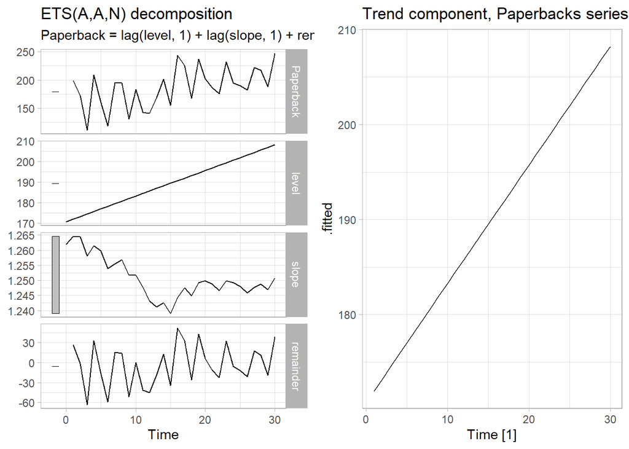

```r
components_pb<-components(paperback_model)%>% autoplot()+ theme_light()

# manually extract the trend component
trend_pb<- fitted(paperback_model, component = "trend") %>%
  autoplot() +
  labs(title = "Trend component, Paperbacks series")+theme_light()

plot_grid(components_pb, trend_pb)
```

- Plotting the components we see that the slope changes not staying constant over time, as anticipated above. It is computed as $y_t-y_{t-1}$. It moves within a range of (1.240; 1.265).
- The initial level value ($y_1$) is 170.699, the initial slope ($y_2-y_1$) amounts to 1.262.
- The smoothing parameters are very low indicating that a lot of weight is given to past observations,resulting in a smooth estimate of the trend element. It is a straight line when we look at the plot.
- Same is valid for the alpha and the level component (average value per time period) which, in fact, when plotted is positively sloped straight line.

```r
# Building the forecast
fc_paperbacks<- paperback_model %>%
  fabletools::forecast(h=1)
fc_paperbacks %>% kbl()%>% kable_styling()
```

| .model | Time | Paperback | .mean |
| --- | --- | --- | --- |
| AAN | 31 | N(209, 1119) | 209.4602 |

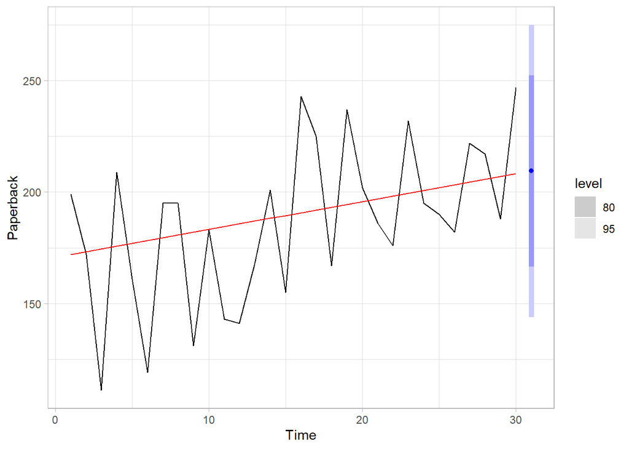

```r
# Plot data and forecast
fc_paperbacks %>%
  autoplot(books_tsibble[,c(1,2)]) +
  geom_line(aes(y = .fitted), col="red",
            data = augment(paperback_model))+
  theme_light()
```

The forecast is built for `h=1` because we want to know if paperbacks will exceed hardcovers’ sales **next time.**

Our forecast follows: $y_{t+1}=L_t+T_t+ E_{t+1} \sim N(L_t+T_t, \sigma^2)$. $E_{t+1}$ is the unobserved independent innovation normally distributed. In this case we are not computing the distribution of aggregation h-step ahead since h=1.

In general, the h steps ahead forecast can be written as: $y_{t+h}= L_t+hT_t+ E_{t+h}+ \sum^{h-1}_{j=1}(\alpha + j \beta)E_{t+h_j}$

#### a.2 Hardcovers

```r
# Fitting model
hardcovers_model <- books_tsibble[,c(1,3)] %>%
  model(
    AAN = ETS(Hardcover ~ error("A") + trend("A") + season("N"))
    )

report(hardcovers_model)
```

```
## Series: Hardcover
## Model: ETS(A,A,N)
##   Smoothing parameters:
##     alpha = 0.0001000484
##     beta  = 0.0001000231
##
##   Initial states:
##      l[0]     b[0]
##  147.7935 3.302946
##
##   sigma^2:  853.2586
##
##      AIC     AICc      BIC
## 310.2148 312.7148 317.2208
```

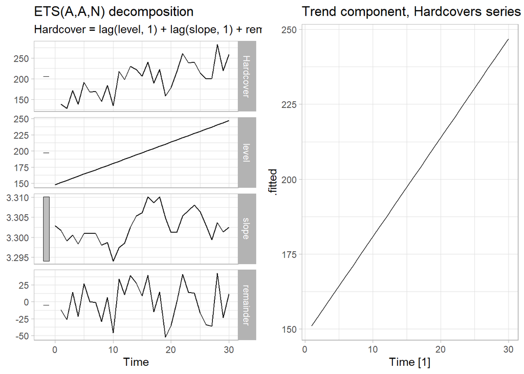

```r
components_hc<-components(hardcovers_model)%>% autoplot()+ theme_light()

# manually extract the trend component
trend_hc<- fitted(hardcovers_model, component = "trend") %>%
  autoplot() +
  labs(title = "Trend component, Hardcovers series")+theme_light()

plot_grid(components_hc, trend_hc)
```

The ETS model fits this time series in a similar way to the Paperbacks series. - The slope moves within the range of (3.295; 3.310). Compared to Paperbacks we can say that the sales of Hard-covers grows more over the observed time span. - The overall increment of the level over time is larger than the one observable for paperbacks’ sales. - Regarding the *Remainder*, both series do not seem overly random, but we keep working with the model A,A,N for simplicity.

```r
# Building Forecast
fc_hardcovers<- hardcovers_model %>%
  fabletools::forecast(h=1)
fc_hardcovers %>% kbl()%>% kable_styling()
```

| .model | Time | Hardcover | .mean |
| --- | --- | --- | --- |
| AAN | 31 | N(250, 853) | 250.172 |

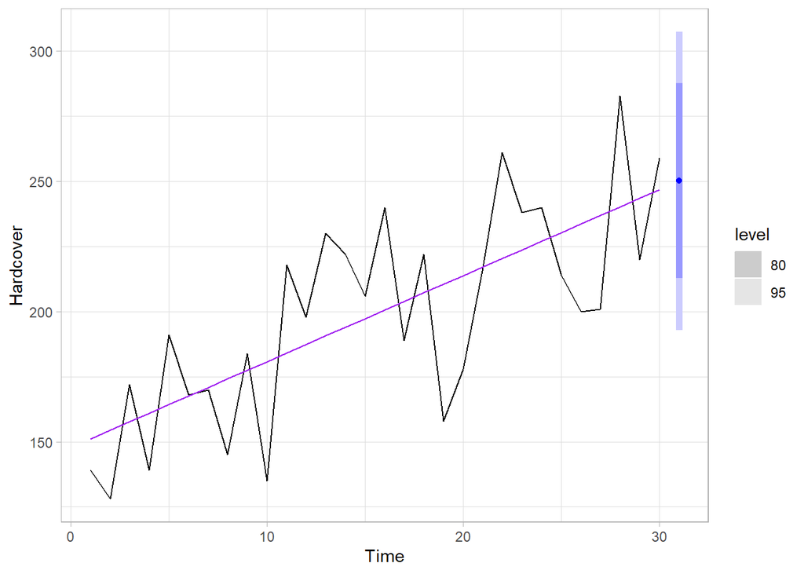

```r
# Plot data and forecast
fc_hardcovers %>%
  autoplot(books_tsibble[,c(1,3)]) +
  geom_line(aes(y = .fitted), col="purple",
            data = augment(hardcovers_model))+
  theme_light()
```

The predictions is build the same way as the one above The forecast for the 31st period amounts to 250.172, which is the centre of the confindence interval of prediction.

### b. Simulate 2 sets of 1000 random normal variables associated with each model.

As previously stated the 2 forecasts we generated follow the $N(L_t+T_t, \sigma^2)$ distribution. The one step ahead prediction is $L_t+T_t$ plus some error we expected to have mean equal 0.

- The mean of the distribution of the randomly generated 1000 points for both groups will be the forecast above generated.
- The variance of the distribution for the random generation will be the one from the A,A,N model.

#### b.1 Paperbacks Sales

```r
set.seed(5678)
report(paperback_model)
```

```
## Series: Paperback
## Model: ETS(A,A,N)
##   Smoothing parameters:
##     alpha = 0.0001002281
##     beta  = 0.0001000024
##
##   Initial states:
##     l[0]     b[0]
##  170.699 1.261911
##
##   sigma^2:  1118.663
##
##      AIC     AICc      BIC
## 318.3396 320.8396 325.3456
```

```r
# SD
sigma <- sqrt(1118.663)
sigma
```

```
## [1] 33.44642
```

```r
# mean
mean<-fc_paperbacks$.mean
mean
```

```
## [1] 209.4602
```

```r
# generating the normally distributed random variables
# pertinent to paperbacks sales
sim_y_t1=rnorm(n=1000, mean = mean, sd=sigma)
```

#### b.2 Hardcover Sales

```r
set.seed(1234)
report(hardcovers_model)
```

```
## Series: Hardcover
## Model: ETS(A,A,N)
##   Smoothing parameters:
##     alpha = 0.0001000484
##     beta  = 0.0001000231
##
##   Initial states:
##      l[0]     b[0]
##  147.7935 3.302946
##
##   sigma^2:  853.2586
##
##      AIC     AICc      BIC
## 310.2148 312.7148 317.2208
```

```r
#SD
sigma_hc <- sqrt(853.2586)
sigma_hc
```

```
## [1] 29.21059
```

```r
# mean
mean_hc<-fc_hardcovers$.mean
mean_hc
```

```
## [1] 250.172
```

```r
# generating the normally distributed random variable
# pertinent to hardcovers sales
sim_w_t1=rnorm(n=1000, mean = mean_hc, sd=sigma_hc)
```

### c. Estimate the probability P(yt+1> wt+1) for the corresponding proportion.

```r
# comapre the 2 groups or random variables
comparison <- sim_y_t1<sim_w_t1

#proportion of times when yt+1>wt+1
proportion <- sum(comparison)/length(comparison)
1-proportion
```

```
## [1] 0.185
```

There seem to be an 18.5% chance of paperbacks sales exceeding the Hardcovers sales within the context of the simulation we ran. At the start we have noticed how hardcovers grew more of the observed time period, yet paperbacks’ sales started off at a higher point from period 0. These and other factors have influenced the data, and so the mean of the forecast around which the distributions of the simulations move around with their respective variances.

### d. Under which assumptions the computation on the point c. before can be performed?

In this case we used the A,A,N model as required, without checking the residuals of the fitted model. We built our forecasts and our simulations assuming that the error terms (“innovations”) $E_{t+h-j}$, where j=1, have expected value 0. That can be assumed in the case in which we selected the model that does the best job at modelling autocorrelation out of the `Remainder` components of our fitted models. For reference we check the acf plots of the residuals:

##### Diagnostics on Paperbacks Sales Fitted model

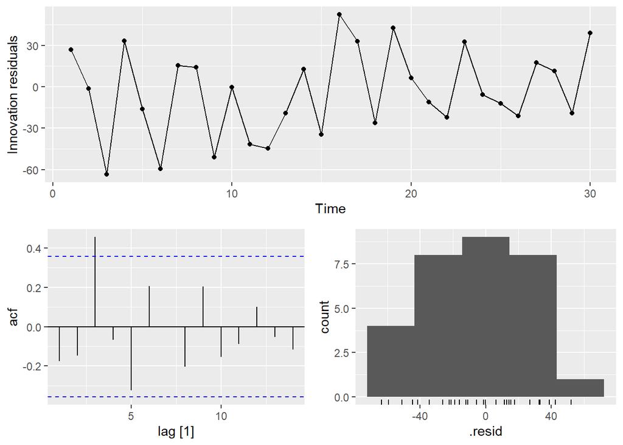

```r
paperback_model%>% gg_tsresiduals()
```

We see in the acf plot that one of the lags is significant, that indicates that not all autocorrelation has been modelled out of the series. Moreover, the histogram does not seem to depict a properly normal distribution, it is not simmetric.

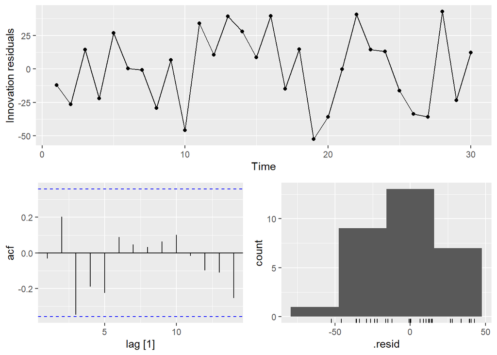

```r
hardcovers_model%>% gg_tsresiduals()
```

For the Hardcovers series the situation is more fortunate when looking at the acf plot, no significance is detected. Yet the histogram does not look lightailed nor symmetric.

We can that the A,A,N model does a good enough job at using all the information in the series, the residuals seem uncorrelated enough. And their distributions have mean 0, meaning the forecast is not biased. Yet, considered the graphic limitation they do not seem normally distributed.

Under this normality assumption we have generated the 2 groups of random variables respecting their distributions. In conclusion, we should pay more attention to the performance of our models so to select the best one and have the assumption satisfied.